[figure not shown]

# SMU Master's of Science Data Science

# MSDS 7330: File Organization and Database Mangement

### Authors: Casey Martinez, Kyle Thomas, Matthew Rega

#### Spring 2018

#### **Introduction:**

Wind turbine operators face a competitive marketplace for selling power. The historically low price of natural gas and the amazing success of solar and wind power has created thin margins. This has greatly benefited customers and the environment. Since the upfront costs are fixed, the operating cost of the wind farm can be the difference between making money and losing money in the long-term. In recent years there have been advances in technology and economies of scale that have made great improvements in the uptime of equipment. One such improvement is vibration analysis also called condition monitoring. These techniques have been widely adopted in other industries with high capital costs and strict uptime constraints (i.e. [aircraft](https://www.sciencedirect.com/science/article/pii/S0888327006001312), [gas turbines](http://www.journalrepository.org/media/journals/BJAST_5/2016/Jan/AlAdawi1422015BJAST23163.pdf), etc.). Vibration analysis is a way to interpret data from accelerometers attached to various parts of rotating equipment. Changes in the vibration signals can predict equipment failure in advance. This allows for repairs to be better planned before catastrophic damage has taken place.

[Pattern Energy](https://patternenergy.com/) is one such wind turbine operator that utilizes this approach to drive down operating costs. They have graciously allowed us to sample their data for this study. Vibration sensors are installed on various rotating parts inside the wind turbine. In this study, we will focus on data from the main bearing. This bearing connects the low-speed shaft from the hub to the nacelle structure where it can engage the gearbox. The gearbox will then step up the rotation speed for proper engagement with the generator where the electricity is produced. We focus on the main bearing here due to known failures in the sample data set.

In this report, we will outline the following:

- A basic overview of the vibration data
- How it is currently stored in the local MySQL database
- Why we chose MongoDB
- How we migrated the data
- How we query MongoDB to generate a basic analysis.
- Future work

Fig. 1: Turbine Nacelle Diagram

[figure not shown]

[[source]](https://hackernoon.com/mongodb-vs-mysql-comparison-which-database-is-better-e714b699c38b)

#### **Vibration Analysis:**

The goal of vibration analysis is simple: convert raw acceleration data into actionable information but teasing apart all the sources of vibration in a complex system. Figure 2 is an illustration of how multiple sources of vibration can add together. The grey, gold, and green lines represent various sources of vibration from the bearing raceways, rolling elements, or shaft. The RED line is the sum of the three separate signals. The data collected from the sensor will only give the RED summation. Fortunately, there is a mathematical operation that can help called the [Fast Fourier Transform](https://en.wikipedia.org/wiki/Fast_Fourier_transform) (FFT). Figure 3 illustrates how the FFT operation allows us to separate the sources of vibration into its components. The left time axis shows the combined signal described earlier. The right frequency axis shows the distinct peaks for the separate sources of vibration. This FFT analysis can be done for a variety of frequency ranges to give more details on certain areas of interest. Using the geometry of the equipment and the rotation speed of the shaft, we can compute the expected frequency of the components of the bearing. This allows one to diagnose specific defects based on the FFT peaks. For example, since the shaft rotation speed and the number of roller bearings are known, we can calculate the expected frequency of the outer raceway defect shown in figure 4. More information can be found [here](http://www.maintenanceonline.co.uk/maintenanceonline/content_images/p32-42%20Lacey%20paper%20M&AM.pdf) and [here](https://www.youtube.com/watch?v=5MNyLM0N6l0).

Fig. 2: Sine wave addition

[figure not shown]

[[source]](https://hackernoon.com/mongodb-vs-mysql-comparison-which-database-is-better-e714b699c38b)

Fig. 3: FFT Illustration

[figure not shown]

[[source]](https://hackernoon.com/mongodb-vs-mysql-comparison-which-database-is-better-e714b699c38b)

Fig. 4: Bearing Defect Example

[figure not shown]

[[source]](https://hackernoon.com/mongodb-vs-mysql-comparison-which-database-is-better-e714b699c38b)

#### **Current MySQL Structure:**

The sample data provided by Pattern Energy was stored on the wind farm local server in a MySQL database. The sensors and database were installed by a third party to shutdown the turbine direcly if a alarm condition takes place. Based on a defined schedule, measurements are taken from the sensors and a suite of analysis are performed and saved. Proprietary software is used to setup the alarms, schedules, and to view the data(see figure 5 below). The structure of the database works fine for the proprietary software but is not easily accessable for reporting or modeling. The raw data is stored as a compressed hexidecimal [BLOB](https://dev.mysql.com/doc/refman/8.0/en/blob.html). This is a way to store unstructured data in SQL but the BLOB cannot be queried directly(see figure 6 below). We will outline a better way to store this unstructured data efficiently and make the data available for modeling and reporting. The first step was to copy a sample of data to a Google Cloud MySQL instance(see figure 7 below).

Fig. 5: Proprietary Software

[figure not shown]

Fig. 6: MySQL Database

[figure not shown]

Fig. 7: Google Cloud

[figure not shown]

#### **Why MongoDB?:**

MongoDB is a document-style database that stores data in flexible, JSON-like documents, making it easy combine data of any structure. In this context, you can think of the documents as JSON BLOBs. Unlike the MySQL BLOBs, the data can queried. The main differences between MongoDB and MySQL are that the database schema can change dynamically and the database size can scale horizontally. This means if a new wind farm is added to the database with different components or new analysis techniques are developed, there is no need to force these changes into a rigid data-type constrained schema. Also, as the volume of data increases, additional clusters can be added to the network to support this growth without having to resort to partitioning or compression. MongoDB manages the 'sharding' of the data across multiple clusters to maintain reliability and availability. The other differences are shown below in figure 8. A list of companies that use MongoDB can be found [here](https://www.mongodb.com/who-uses-mongodb). The terminology of MongoDB is different than MySQL and the translation is shown in figure 9. Since we are storing raw data from a variety of sensors and analysis(i.e. raw time-series, FFT, etc.), we don't want to setup a rigid schema structure for each one.

Fig. 8: MySQL vs. MongoDB

[figure not shown]

[[source]](https://hackernoon.com/mongodb-vs-mysql-comparison-which-database-is-better-e714b699c38b)

Fig. 9: Terminology

[figure not shown]

[[source]](https://dzone.com/articles/why-mongodb)

#### **MySQL to MongoDB Migration:**

The overall goal of the code shown below was to generalize a process that pulled the data from MySQL, manipulate the data, and then easily uploaded it to MongoDB. This was done by writing a series of functions that can pass data to one-another. Below is a breakdown of the functions and what they were used for. Most of the functions work together, but they can be used separately.

- **investigate** - This function simply connects to the MySQL database, runs a query, and returns the results. It is the first step in creating a pipeline to query the data.
- **decode_object** – This function was used to decode the blob returned from the MySQL database. It relies on the schema of the database to access the blob.
- **xml_to_dictionary** – This function takes the decoded object from the previous function and converts everything from XML to a more useable form that MongoDB can easily understand. This utilizes the xmltodict library to do most of the heavy lifting.
- **push_to_Mongo** – This function pushes two data sets (meta-data and raw-data) and inserts those objects into a defined MongoDB database and collection. The datasets should be python dictionaries.
- **set_up** - The goal of this function is to write many results from an sql query to mongoDB. The main disadvantage of this is that everything is inserted in the same DB and collection. This means that you have to be very aware of what you are querying. The function takes an object that has been decoded and converted to xml (db_obj argument in the function), a mongodb database name, and a collection name (the database and collection are created on the fly if they do not exist). The main problem with this function is that it inserts everything at once and can create a problem with memory management (this function crashed Mongo once).
- **chunks** - The goal of this function is to break apart queries to prevent memory problems. Based on some empirical testing, it seems like the system can handle about 50 queries at a time before a memory problem occurs. A generator object is used to more effectively handle memory while passing data to the MongoDB.
- **run_data** - This function brings everything together, you define what you want to query and insert into the database. This allows you to define the turbines and the FFTs that you want to put into the system. The function then loops through the turbines, queries MySQL, and uses all of the other functions to push everything to Mongo.

The final results in MongoDB are shown in figures 10 and 11 below.

```python
import pymysql.cursors
import gzip
import binascii
import json
import xml.etree.ElementTree as ET
import matplotlib as mpl
import xmltodict
from pymongo import MongoClient
from json import dumps
from itertools import chain
```

```python
# This function simply connects to the MySQl database, runs a query, and returns the results
# First step in creating a pipeline to query the data.
def investigate(my_query):

    if type(my_query) != str:
        my_query = str(my_query)

    if ";" not in my_query:
        my_query += ";"


    connection = pymysql.connect(host='35.190.137.94',
                             user='user2',
                             password='pattern',
                             cursorclass=pymysql.cursors.DictCursor)
    try:
        with connection.cursor() as cursor:
            query = my_query
            cursor.execute(query)
            dfName = cursor.fetchall()
            #print(results)
    finally:
        return(dfName)
        connection.close()

test = investigate(my_query="SELECT * FROM msys.`data#t009` where ID = 877;")
test
```

```
[{'ConditionKey': 'WPS-ActivePower 921-1150,',
  'HalfLifeDays': 100,
  'ID': 877,
  'LocationName': 'T009',
  'MeasurementKey': '/T009/Main bearing/FFT_16000',
  'Overload': 0,
  'RPM': 1228.3086,
  'Record': b'\x1f\x8b\x08\x00\x00\x00\x00\x00\x00\x00\xbd]\xdbr\x1b\xc7v}\xb6\xbe\x82\xe5\xe7\x10\xe8\xfbE\x05\xe3\x94,Y\xf6\xa9c\xd9*I\xb6\xe2J\xa5T\x109\x92\x11\x93\x80\x02\x80\xb6u>+\x9f\x90/\xcb\xdas\xe9\xbd\x86\xa4\x14\xe7%\xf6\x83\xd8\xd3=}\xdd\x97\xb5/=X\xfd\xed\xcf\xeb\xab\xb3\xdf\xbb\xc3q\…
  'RedAlarm': 0,
  'TimeClosed-Min': 1440,
  'Trigger_Time': datetime.datetime(2015, 6, 17, 22, 15, 27),
  'WPS-ActivePower-Average': 1046.0,
  'WPS-ActivePower-Deviation': 0.0,
  'YellowAlarm': 0}]
```

```python
# This function was used to decode the blob returned in the MySQL database
# Very taylored to the schema of the MySQL database
def decode_object(db_object, field = 'Record'):
    if type(field) != str:
        field = str(field)

    try:
        unzipped = gzip.decompress(db_object[field]) #if only using this once, may need to call db_object[0]
    except ValueError:
        print('Object has no "Record" field or no specified field found. Try again with a different object field selected')

    decoded = bytes.decode(unzipped)

    return(decoded)

test2 = decode_object(test[0])
print(test2)

# Option 2 - use xmltodict library
# This method is much faster. Converting it to a function so it can be used repeatedly
# This function takes the decoded object and then converts it to XML so that MongoDB can easily ingest the data
def xml_to_dictionary(decoded_object):
    array_output = xmltodict.parse(decoded_object)
    return(array_output)
```

```
<?xml version="1.0" encoding="utf-8"?>
<Record><Version>1</Version><Site><EnterpriseUsersTime>2015-04-07 13:57:24</EnterpriseUsersTime><EnterpriseOwner>Brande TCM Enterprise</EnterpriseOwner><ServerConfigurationTime>2015-06-17 10:50:45</ServerConfigurationTime><ConfigurationFileTime>2015-06-17 12:55:52</ConfigurationFileTime><Configurati…
		<SiteName>Site</SiteName>
		<SiteID/>
		<NumberOfLocations/>
		<HostName/>
		<EmailTo/>
		<SystemEmailTo/>
		<ReportEvery/>
		<SiteState/>
	</Site><Location>
<LocationType>M-System</LocationType>
<LocationName>T009</LocationName>
<SerialNumber>2308969</SerialNumber>
<HostName>10.176.242.217</HostName>
<WPSHostName>10.176.242.216:48003</WPSHostName>
<RPMSource>2</RPMSource>
<RPMDivider>1</RPMDivider>
<RPMFactor>1</RPMFactor>
<IECLDName>IEC</IECLDName>
<WPSProtocol>IEC-http</WPSProtocol>
<CommissionedSerialNumber>5100079130</CommissionedSerialNumber></Location><Sensor><SensorType>M-channel</SensorType><SensorName>Main bearing</SensorName><SensorAddress>1</SensorAddress><Gain>1</Gain><SensorLicense>C</SensorLicense><OverloadAction>AlarmReject</OverloadAction><Owner>tkm</Owner><Sensit…
            <ConfigurationOwner>Brande TCM Enterprise</ConfigurationOwner><ConfigurationName>2.3 MW VS M-sys5 - i=90.842</ConfigurationName>
            <AlarmEmailTo/>
            <TurbineType>2.3 MW VS</TurbineType>
            <GearRatio>90.842</GearRatio>
            <VariableSpeed>Yes</VariableSpeed>
            <NetFrequency/>
            <RPMSource>0</RPMSource>
            <RPMDivider>1</RPMDivider>
            <RPMFactor>1.0</RPMFactor>









```

[output cut: 55 more lines]

```
    <BinName>1910-2185</BinName>
    <Min>1910</Min>
    <Max>2185</Max>
    <Tolerance>656</Tolerance>
  </Bin><Bin>
    <BinName>2186-2415</BinName>
    <Min>2186</Min>
    <Max>2415</Max>
    <Tolerance>725</Tolerance>
  </Bin><Bin>
		<BinName>2416-3000</BinName>
		<Min>2416</Min>
		<Max>3000</Max>
		<Tolerance>900</Tolerance>
	</Bin><WPS-ActivePower-Average>1046</WPS-ActivePower-Average><WPS-ActivePower-Minimum>1046</WPS-ActivePower-Minimum><WPS-ActivePower-Maximum>1046</WPS-ActivePower-Maximum><WPS-ActivePower-Deviation>0</WPS-ActivePower-Deviation><WPS-ActivePower-StartTime>2015-06-17 22:15:27</WPS-ActivePower-StartTim…
```

```python
# This function can be used to push multiple objects to the same collection in a selected database
def push_to_Mongo(db_name, collection_name, mdata, rdata):
    """This function takes a two python dicitonaries and inserts them into
    the defined MongoDB database and the defined collection.
    Both mdata and rdata should be python dictionaries. Use xml_to_dictionary to convert
    the decoded SQL blob (XML) to a dictionary."""

    if type(db_name) != str:
        db_name = str(db_name)

    # Connect to mongo and define database name
    client = MongoClient('localhost', 27017)
    db = client[db_name]

    collection = eval("db." + str(collection_name))

    data = {
        "MetaData" : mdata,
        "RawData": rdata
    }

    result = collection.insert_one(data)
    print('One insert: {0}'.format(result.inserted_id))
```

```python
# The goal of this function is to write many results from an sql query to mongoDB
# The main disadvantge of this is that everything is inserted in the same DB and collection.
# This means that you have to be very aware of what you are querying
# The function takes an object that has been decoded and converted to xml (db_obj in the function), a mongodb databsae name
# and a collection name (the db and collection are created on the fly if they do not exist).
# The main problem with this function is that it inserts everything at once. It created a problem with memory (crashed Mongo
# once)
def set_up(db_obj, mongo_db_name, mongo_collection):
    for x in range(len(db_obj)):
        _decoded = decode_object(db_obj[x])
        db_obj[x].pop('Record')
        _meta = db_obj[x]
        _raw = xml_to_dictionary(_decoded)

        push_to_Mongo(mongo_db_name, mongo_collection, _meta, _raw)
```

```python
# The goal of this function is to break apart queries to prevent memory problems. It seems like the systems can handle about 50
# queries at a time befor a memory problem. So I will chunk this process up.
# Function was repurposed from stack overflow
# used for testing  ---> sql_obj = investigate("SELECT * FROM msys.`data#t009` where MeasurementKey LIKE '%FFT%' limit 100")

def chunks(l, n):
    """Yield successive n-sized chunks from l."""
    for i in range(0, len(l), n):
        yield l[i:i + n]

# sql_obj = investigate("select * FROM msys.`data#t001` where MeasurementKey = 'Site/T001/Main bearing/FFT_16000'")

# Testing the function:
# for var in chunks(sql_obj, 50):
#     set_up(var,  'T001', 'FFT_16000')
```

```python
# This function brings it all together, you define what you want to query and insert into the database, be warned that this can
# take a lot of time to run, I really should suppress the print function... too late now. To do in the future.
# This allows you to define the functions (which should be a *args argument) and the FFTs that are in the system.
# The function then loops through everything, queries MySQL, and uses all of the other funcitons to push everything to Mongo.

def run_data():
    turbines = ["001", "002", "003", "009"]
    ffts = """/Main bearing/FFT_0-1000
/Main bearing/FFT_0-1000_2_Tr
/Main bearing/FFT_0-1000_Tr
/Main bearing/FFT_1000p_Tr
/Main bearing/FFT_16000
/Main bearing/FFT_16_Tr
/Main bearing/FFT_250_Tr
/Main bearing/FFT_35_Tr""".split("\n")

    for x in turbines:
        for f in ffts:
            # define the collection name by taking the end of the fft
            colname = str(f.split("/")[-1].replace("-",""))
            sql_obj = investigate("select * from msys.`data#t"+x+"` where MeasurementKey = 'Site/T" +x + f + "'")
            for var in chunks(sql_obj, 50):
                set_up(var, "T"+x, colname)
#             del(sql_obj)
```

```python
# Inserting another collection into Mongo using functions
sql_obj = investigate("select * FROM msys.mask;")
set_up(sql_obj, 'masks', 'LGW')
# test = investigate("select * from msys.`data#t001` where MeasurementKey = Site/T001/Main bearing/FFT_16000")
# test
```

```
One insert: 5ada36655fb98c6aa14c7b57
One insert: 5ada36655fb98c6aa14c7b59
One insert: 5ada36655fb98c6aa14c7b5b
One insert: 5ada36655fb98c6aa14c7b5d
One insert: 5ada36655fb98c6aa14c7b5f
One insert: 5ada36655fb98c6aa14c7b61
One insert: 5ada36655fb98c6aa14c7b63
One insert: 5ada36655fb98c6aa14c7b65
One insert: 5ada36655fb98c6aa14c7b67
One insert: 5ada36655fb98c6aa14c7b69
One insert: 5ada36655fb98c6aa14c7b6b
One insert: 5ada36655fb98c6aa14c7b6d
One insert: 5ada36655fb98c6aa14c7b6f
One insert: 5ada36655fb98c6aa14c7b71
One insert: 5ada36655fb98c6aa14c7b73
One insert: 5ada36655fb98c6aa14c7b75
One insert: 5ada36655fb98c6aa14c7b77
One insert: 5ada36655fb98c6aa14c7b79
One insert: 5ada36655fb98c6aa14c7b7b
One insert: 5ada36ab5fb98c6aa14cb9a3
```

```python
# This function brings it all together, you define what you want to query and insert into the database, be warned that this can
# take a lot of time to run, I really should suppress the print function... too late now. To do in the future.

# This was the first iteration of the funciton. Left in for historical purposes.
def run_data():
    turbines = ["001", "002", "003", "009"]
    ffts = """Main bearing/rms_main_175_Tr""".split("\n")

    for x in turbines:
        for f in ffts:
            colname = str(f.split("/")[-1].replace("-",""))
            sql_obj = investigate("select * from msys.`data#t"+x+"` where MeasurementKey = 'Site/T" +x + f + "'")
            for var in chunks(sql_obj, 50):
                set_up(var, "T"+x, colname)
#             del(sql_obj)

#Site/T009/Main bearing/rms_main_175_Tr
#run_data()
```

Fig. 10: Basic MongoDB

[figure not shown]

Fig. 11: MongoDB vs. BLOB

[figure not shown]

#### **PyMongo Querying and Reporting:**

```python
import pandas as pd
import matplotlib as mpl
import matplotlib.pyplot as plt
import pymongo
import re
import datetime
```

```python
# Connect to mongo and define database name
client = pymongo.MongoClient('localhost', 27017)
# There are turbines T001, T002, T003, and T009
db = client["T001"]
```

```python
# show the collection names
db.collection_names()
```

```
['FFT_16000',
 'FFT_01000_2_Tr',
 'FFT_250_Tr',
 'FFT_01000_Tr',
 'FFT_1000p_Tr',
 'FFT_16_Tr',
 'FFT_35_Tr',
 'FFT_01000']
```

```python
#Query one collection
one = db.FFT_01000.find_one()
x = one.get('T009_Measurments')['Trigger_Time']
```

[output not shown]

```python
# Get the raw data, this is how we will access the raw viration data.
# Simple example to show structure of the format
raw = one.get('T009_RawData')['Record']['Measurement']['DataSets']['DataSet']['Values']
```

```python
# convert data to float
# To plot with matplotlib the data must be nueric (float in this case). Used an ananomous function and map to acomplish this
raw_float = list(map(lambda x: float(x), raw.split()))
```

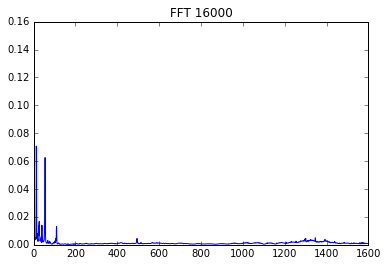

```python
# Plot the data
# Simple example
%pylab inline
plt.plot(raw_float)
plt.title("FFT 16000")
plt.show()
```

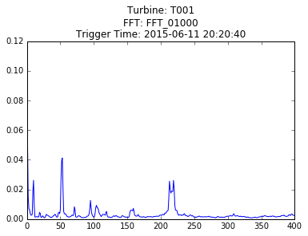

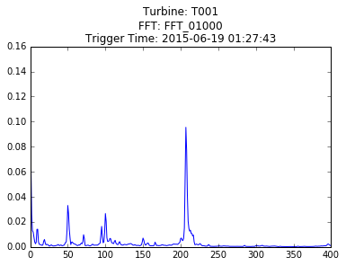

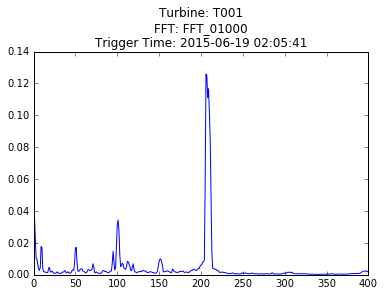

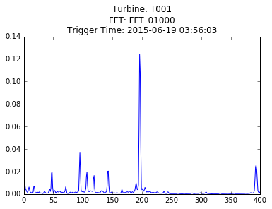

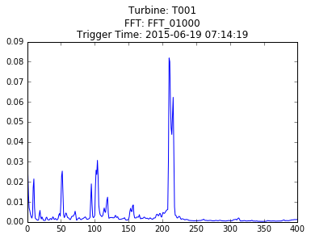

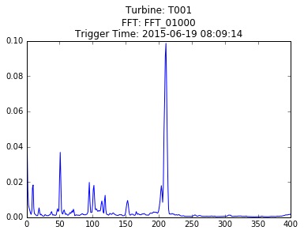

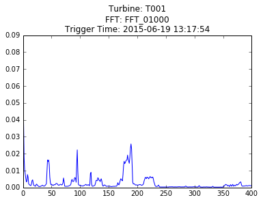

```python
# This fucntion allows the user to plot FFTs for a chose turbine between two date ranges.
# More information is in the help area of the function.
# This function plots out the FFTs one at a time. If there were more time I would plot them out in 3D so that
# the impact could be seen over time.
def plotFFT(turbine, fft, start, end):
    """This function take a turbine (ex 'T001') an FFT type that is a collection name in mongodb(ex 'FFT_01000').
    The function also takes a start and end date that should be a string in the following format: Year-Month-Day
    (ex '2015-05-22'). The function returns a series of plots that shows the fft between the start and end date."""


    client = pymongo.MongoClient('localhost', 27017)
    db = eval("client['" + turbine +"']")

    _start = datetime.datetime.strptime(start, "%Y-%m-%d")
    _end = datetime.datetime.strptime(end, "%Y-%m-%d")

    dttm2 = eval("db." + fft + ".find({'T009_Measurments.Trigger_Time' : { '$gte': datetime.datetime(" + str(_start.year) + ", "
                 +str(_start.month) + ", "
                 + str(_start.day) + ", 0, 0, 0), '$lte': datetime.datetime(" + str(_end.year) + ", "
                 + str(_end.month) + ", "
                 + str(_end.day) + ", 0, 0, 0)}})")


    for doc in dttm2:
        raw2 = doc.get('T009_RawData')['Record']['Measurement']['DataSets']['DataSet']['Values']
        date_obj = doc.get('T009_Measurments')['Trigger_Time']
        raw_float2 = list(map(lambda x: float(x), raw2.split()))
        %pylab inline
        plt.plot(raw_float2)
        plt.title("Turbine: " + turbine + "\n" + "FFT: " + fft + "\n"
                  + "Trigger Time: " + datetime.datetime.strftime(date_obj, "%Y-%m-%d %H:%M:%S"))
        plt.show()


plotFFT("T001", "FFT_01000", "2015-06-01", "2015-06-30")
```

Fig. 12: Changes of FFT

[figure not shown]

#### **Conclusion and Future Work:**

Below is a list of future work include exciting machine learning opportunities.

- Reorganize the highly nested BLOB data into a flatter structure
- Implement sharding to demonstrate the horizontal scalability of MongoDB.
- Machine Learning Opportunities:
- Break apart the FFT data into various frequency ranges and treat each one as a time series.
- Combine vibration and bearing temperature to create a more sensitive model.
- Compare a turbine's data to a site median or cluster median based on similar performance.
- Develop Turbine Health Dashboards
- Evaluate other cloud platforms for hosting database
- This project on Google Cloud Platform cost about $150 of a $300 starting gift.
- Try MongoDB's own [Atlas](https://www.mongodb.com/cloud/atlas) database-as-a-service platform.
- Integrate API to easily share data
- Interface database with site server in real time with [MQTT communication protocol](https://www.mqtt.org) and [edge hardware](https://www.researchgate.net/file.PostFileLoader.html?id=5698da1f5cd9e39aa78b45ea&assetKey=AS%3A318123192848384%401452857887254).

Fig. 12: Growth of Internet of Things(IoT)

[figure not shown]

[[source]](https://www.forbes.com/sites/louiscolumbus/2017/12/10/2017-roundup-of-internet-of-things-forecasts/#763cc5d1480e)